# Insuficiencia_cardiaca

## EDA Heart-Disease

This dataset contains medical information from 302 patients who had heart failure or who are at risk of heart attacks. This data was collected during a follow-up period, where each patient profile has 13 clinical characteristics.

Using the information in the dataset, an exploratory data analysis (EDA) will be performed, which will allow us to visualize which characteristics most affect the patient with this pathology and then perform a classification with the Logistic Regression model that allows us to calculate the probability of the patient dying during a period of time. The Target variable is coded as 1 if the patient is sick and 0 if he is not.

**Feature Details**

https://www.kaggle.com/datasets/johnsmith88/heart-disease-dataset

> - Age (age in years)
> - Sex (1 = male; 0 = female)
> - CP (chest pain type)
>   - Value 1: typical angina
>   - Value 2: atypical angina
>   - Value 3: non-anginal pain
>   - Value 4: asymptomatic
> - TRESTBPS (resting blood pressure (in mm Hg on admission to the hospital))
> - CHOL (serum cholestoral in mg/dl)
> - FPS (fasting blood sugar > 120 mg/dl) (1 = true; 0 = false)
> - RESTECH (resting electrocardiographic results)
> - THALACH (maximum heart rate achieved)
> - EXANG (exercise induced angina (1 = yes; 0 = no))
> - OLDPEAK (ST depression induced by exercise relative to rest)
> - SLOPE (the slope of the peak exercise ST segment)
> - CA (number of major vessels (0-3) colored by flourosopy)
> - THAL (3 = normal; 6 = fixed defect; 7 = reversable defect)
> - TARGET (1 or 0)

### Load Packages

```python
import pandas as pd
import numpy as np
import matplotlib.pyplot as plt
import seaborn as sns
sns.set_style("darkgrid")
import warnings
warnings.filterwarnings('ignore')
```

### Load Dataset

```python
falla_cardiaca = pd.read_csv('heart.csv')
falla_cardiaca.head()
```

|  | age | sex | cp | trestbps | chol | fbs | restecg | thalach | exang | oldpeak | slope | ca | thal | target |
| --- | --- | --- | --- | --- | --- | --- | --- | --- | --- | --- | --- | --- | --- | --- |
| 0 | 52 | 1 | 0 | 125 | 212 | 0 | 1 | 168 | 0 | 1.0 | 2 | 2 | 3 | 0 |
| 1 | 53 | 1 | 0 | 140 | 203 | 1 | 0 | 155 | 1 | 3.1 | 0 | 0 | 3 | 0 |
| 2 | 70 | 1 | 0 | 145 | 174 | 0 | 1 | 125 | 1 | 2.6 | 0 | 0 | 3 | 0 |
| 3 | 61 | 1 | 0 | 148 | 203 | 0 | 1 | 161 | 0 | 0.0 | 2 | 1 | 3 | 0 |
| 4 | 62 | 0 | 0 | 138 | 294 | 1 | 1 | 106 | 0 | 1.9 | 1 | 3 | 2 | 0 |

### Information of Dataset

```python
falla_cardiaca.info()
```

```
<class 'pandas.core.frame.DataFrame'>
RangeIndex: 1025 entries, 0 to 1024
Data columns (total 14 columns):
 #   Column    Non-Null Count  Dtype
---  ------    --------------  -----
 0   age       1025 non-null   int64
 1   sex       1025 non-null   int64
 2   cp        1025 non-null   int64
 3   trestbps  1025 non-null   int64
 4   chol      1025 non-null   int64
 5   fbs       1025 non-null   int64
 6   restecg   1025 non-null   int64
 7   thalach   1025 non-null   int64
 8   exang     1025 non-null   int64
 9   oldpeak   1025 non-null   float64
 10  slope     1025 non-null   int64
 11  ca        1025 non-null   int64
 12  thal      1025 non-null   int64
 13  target    1025 non-null   int64
dtypes: float64(1), int64(13)
memory usage: 112.2 KB
```

### Null Values

```python
falla_cardiaca.isna().sum().sort_values(ascending=False)
```

```
age         0
sex         0
cp          0
trestbps    0
chol        0
fbs         0
restecg     0
thalach     0
exang       0
oldpeak     0
slope       0
ca          0
thal        0
target      0
dtype: int64
```

### Duplicate Values

```python
falla_cardiaca.duplicated().sum()
```

```
723
```

### Remove Duplicate Values

```python
falla_cardiaca = falla_cardiaca.drop_duplicates()
```

```python
falla_cardiaca.shape
```

```
(302, 14)
```

### Statistics Dataset

```python
falla_cardiaca.describe().T
```

|  | count | mean | std | min | 25% | 50% | 75% | max |
| --- | --- | --- | --- | --- | --- | --- | --- | --- |
| age | 302.0 | 54.420530 | 9.047970 | 29.0 | 48.00 | 55.5 | 61.00 | 77.0 |
| sex | 302.0 | 0.682119 | 0.466426 | 0.0 | 0.00 | 1.0 | 1.00 | 1.0 |
| cp | 302.0 | 0.963576 | 1.032044 | 0.0 | 0.00 | 1.0 | 2.00 | 3.0 |
| trestbps | 302.0 | 131.602649 | 17.563394 | 94.0 | 120.00 | 130.0 | 140.00 | 200.0 |
| chol | 302.0 | 246.500000 | 51.753489 | 126.0 | 211.00 | 240.5 | 274.75 | 564.0 |
| fbs | 302.0 | 0.149007 | 0.356686 | 0.0 | 0.00 | 0.0 | 0.00 | 1.0 |
| restecg | 302.0 | 0.526490 | 0.526027 | 0.0 | 0.00 | 1.0 | 1.00 | 2.0 |
| thalach | 302.0 | 149.569536 | 22.903527 | 71.0 | 133.25 | 152.5 | 166.00 | 202.0 |
| exang | 302.0 | 0.327815 | 0.470196 | 0.0 | 0.00 | 0.0 | 1.00 | 1.0 |
| oldpeak | 302.0 | 1.043046 | 1.161452 | 0.0 | 0.00 | 0.8 | 1.60 | 6.2 |
| slope | 302.0 | 1.397351 | 0.616274 | 0.0 | 1.00 | 1.0 | 2.00 | 2.0 |
| ca | 302.0 | 0.718543 | 1.006748 | 0.0 | 0.00 | 0.0 | 1.00 | 4.0 |
| thal | 302.0 | 2.314570 | 0.613026 | 0.0 | 2.00 | 2.0 | 3.00 | 3.0 |
| target | 302.0 | 0.543046 | 0.498970 | 0.0 | 0.00 | 1.0 | 1.00 | 1.0 |

### Number of Patients with Heart Disease

```python
falla_cardiaca.target.value_counts().sort_index()
```

```
0    138
1    164
Name: target, dtype: int64
```

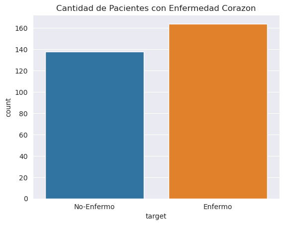

```python
sns.countplot(
    falla_cardiaca['target']
)
plt.xticks([0,1],['No-Enfermo','Enfermo'])
plt.title('Cantidad de Pacientes con Enfermedad Corazón')
plt.show()
```

### Correlation Matrix

```python
falla_cardiaca.corr()
```

|  | age | sex | cp | trestbps | chol | fbs | restecg | thalach | exang | oldpeak | slope | ca | thal | target |
| --- | --- | --- | --- | --- | --- | --- | --- | --- | --- | --- | --- | --- | --- | --- |
| age | 1.000000 | -0.094962 | -0.063107 | 0.283121 | 0.207216 | 0.119492 | -0.111590 | -0.395235 | 0.093216 | 0.206040 | -0.164124 | 0.302261 | 0.065317 | -0.221476 |
| sex | -0.094962 | 1.000000 | -0.051740 | -0.057647 | -0.195571 | 0.046022 | -0.060351 | -0.046439 | 0.143460 | 0.098322 | -0.032990 | 0.113060 | 0.211452 | -0.283609 |
| cp | -0.063107 | -0.051740 | 1.000000 | 0.046486 | -0.072682 | 0.096018 | 0.041561 | 0.293367 | -0.392937 | -0.146692 | 0.116854 | -0.195356 | -0.160370 | 0.432080 |
| trestbps | 0.283121 | -0.057647 | 0.046486 | 1.000000 | 0.125256 | 0.178125 | -0.115367 | -0.048023 | 0.068526 | 0.194600 | -0.122873 | 0.099248 | 0.062870 | -0.146269 |
| chol | 0.207216 | -0.195571 | -0.072682 | 0.125256 | 1.000000 | 0.011428 | -0.147602 | -0.005308 | 0.064099 | 0.050086 | 0.000417 | 0.086878 | 0.096810 | -0.081437 |
| fbs | 0.119492 | 0.046022 | 0.096018 | 0.178125 | 0.011428 | 1.000000 | -0.083081 | -0.007169 | 0.024729 | 0.004514 | -0.058654 | 0.144935 | -0.032752 | -0.026826 |
| restecg | -0.111590 | -0.060351 | 0.041561 | -0.115367 | -0.147602 | -0.083081 | 1.000000 | 0.041210 | -0.068807 | -0.056251 | 0.090402 | -0.083112 | -0.010473 | 0.134874 |
| thalach | -0.395235 | -0.046439 | 0.293367 | -0.048023 | -0.005308 | -0.007169 | 0.041210 | 1.000000 | -0.377411 | -0.342201 | 0.384754 | -0.228311 | -0.094910 | 0.419955 |
| exang | 0.093216 | 0.143460 | -0.392937 | 0.068526 | 0.064099 | 0.024729 | -0.068807 | -0.377411 | 1.000000 | 0.286766 | -0.256106 | 0.125377 | 0.205826 | -0.435601 |
| oldpeak | 0.206040 | 0.098322 | -0.146692 | 0.194600 | 0.050086 | 0.004514 | -0.056251 | -0.342201 | 0.286766 | 1.000000 | -0.576314 | 0.236560 | 0.209090 | -0.429146 |
| slope | -0.164124 | -0.032990 | 0.116854 | -0.122873 | 0.000417 | -0.058654 | 0.090402 | 0.384754 | -0.256106 | -0.576314 | 1.000000 | -0.092236 | -0.103314 | 0.343940 |
| ca | 0.302261 | 0.113060 | -0.195356 | 0.099248 | 0.086878 | 0.144935 | -0.083112 | -0.228311 | 0.125377 | 0.236560 | -0.092236 | 1.000000 | 0.160085 | -0.408992 |
| thal | 0.065317 | 0.211452 | -0.160370 | 0.062870 | 0.096810 | -0.032752 | -0.010473 | -0.094910 | 0.205826 | 0.209090 | -0.103314 | 0.160085 | 1.000000 | -0.343101 |
| target | -0.221476 | -0.283609 | 0.432080 | -0.146269 | -0.081437 | -0.026826 | 0.134874 | 0.419955 | -0.435601 | -0.429146 | 0.343940 | -0.408992 | -0.343101 | 1.000000 |

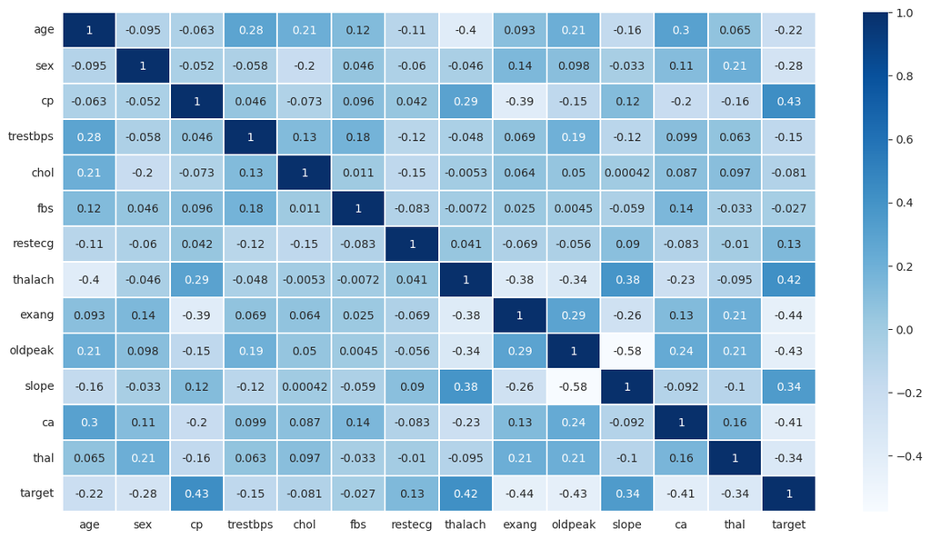

```python
plt.figure(figsize=(15,8))
sns.heatmap(
    falla_cardiaca.corr(),
    cmap='Blues',
    #square=True,
    linewidth=0.1,
    annot= True
)
plt.show()
```

### Number of Sick Patients by Gender

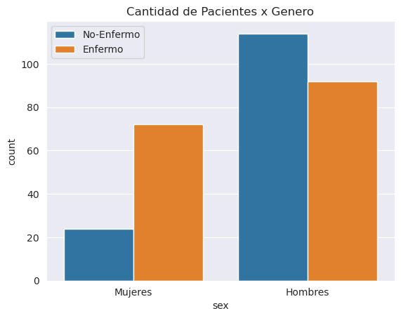

```python
sns.countplot(
    data=falla_cardiaca,
    x='sex',
    hue='target',
)
plt.xticks([0,1],['Mujeres','Hombres'])
plt.legend(labels=['No-Enfermo','Enfermo'])
plt.title('Cantidad de Pacientes x Genero')
plt.show()
```

### Dataset Distribution x Age

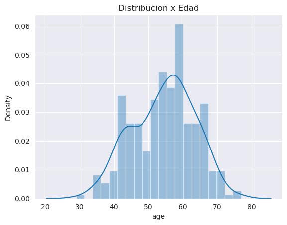

```python
sns.distplot(
    falla_cardiaca['age'],
    bins=20,
    kde=True
).set(title='Distribucion x Edad')
plt.show()
```

### How the Chest pain variable influences Patients

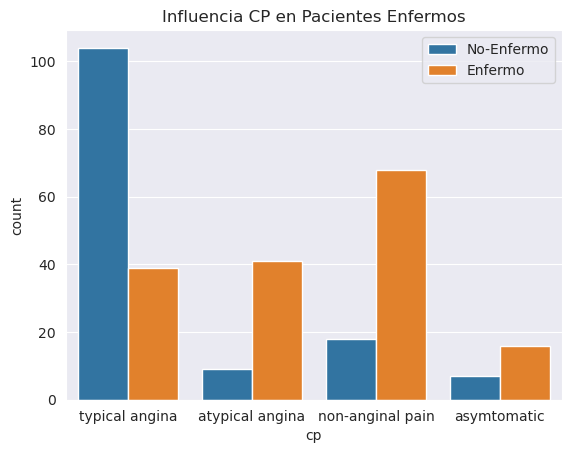

```python
sns.countplot(
    data=falla_cardiaca,
    x='cp',
    hue='target'
)
plt.xticks([0,1,2,3],['typical angina','atypical angina','non-anginal pain','asymtomatic'])
plt.legend(labels=['No-Enfermo','Enfermo'])
plt.title('Influencia CP en Pacientes Enfermos')
plt.show()
```

### How the FBS (fasting blood glucose) variable influences patients

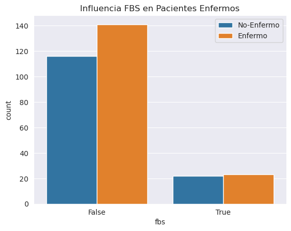

```python
sns.countplot(
    data=falla_cardiaca,
    x='fbs',
    hue='target'
)
plt.xticks([0,1],['False','True'])
plt.legend(labels=['No-Enfermo','Enfermo'])
plt.title('Influencia FBS en Pacientes Enfermos')
plt.show()
```

### Distribution of patients by blood pressure

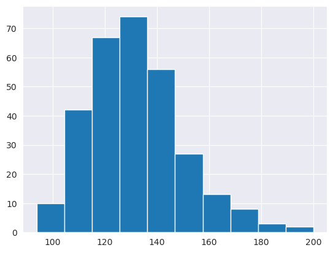

```python
falla_cardiaca['trestbps'].hist()
plt.show()
```

### Distribution of patients by cholesterol

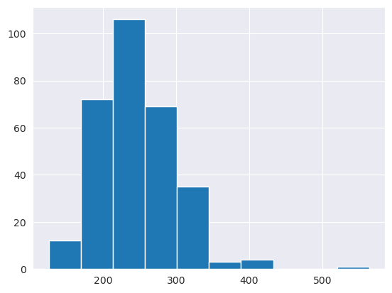

```python
falla_cardiaca['chol'].hist()
plt.show()
```